# Chapter 7 practice questions

```r
require(tidyverse)
require(rethinking)
require(dagitty)
```

## 7E1

Three motivating criteria for information theory:

Overall, information theory is concerned with measuring the reduction in uncertainty about the truth when we learn an outcome. When we don’t have a true test sample, comparing two models’ predictive accuracy is the best we can do. Sometimes even if the true data-generating model is included in the candidate models, a more complex model will outperform it in terms of prediction. So ranking models by any information criterion tells us about their ability to make predictions, not their causal relevance.

Information entropy is continuous, that is, it has no breaks and is not sensitive to small changes in any one probability. It is larger when there are more options for outcomes; or more ways to be wrong. Harder to predict accurately when there are more ways to be wrong. It is additive; so adding additional combinations of events increases the total uncertainty by the additional combinations’ uncertainty.

## 7E2

```r
p <- c( 0.7 , 0.3 )
-sum( p*log(p) )
```

```
[1] 0.6108643
```

## 7E3

```r
p <- c( 0.2 , 0.25,.25,.3 )
-sum( p*log(p) )
```

```
[1] 1.376227
```

## 7E4

```r
p <- c(1/3,1/3,1/3 )
-sum( p*log(p) )
```

```
[1] 1.098612
```

## 7M1 - compare AIC and WAIC

AIC = Akaike Information Criterion. Approximates the cross-validation score of a model, which is itself an approximation of the average relative out of sample KL divergence, or the distance between the information contained in two models relative to the theoretical “true model”. It is the pointwise average log-probability, penalized proportionally to the number of free parameters. This estimate is accurate when:

1. The priors or flat or there is lots of data such that the priors don’t matter
2. The posterior distribution is approximately Gaussian
3. N obs >> number of parameters k

WAIC = Widely Applicable Information Criterion is the more general cousin. It only requires that N>>k, so we can use both informative priors and non-Gaussian distributions. It also is based in the pointwise average log-probability, but it is penalized differently: the sum of the variance in log-probabilities for each observation. Each observation has its own penalty score, which can also function as a measure of overfitting risk.

## 7M2

For model selection, we’re using information criteria to select a candidate model or several candidate models for prediction, discarding the information contained in the criteria used to compare them. Optimizing on predictive accuracy (AIC, WAIC, PSIS, CV) and then using the resulting model for causal analysis will likely result in confounding, because predictive accuracy and causal inference are two separate goals.

In the case of model comparison, the difference in information criteria between models will help us understand the effects of model structure on coefficient estimation, given a set of causal models.

## 7M3

All models must be fit to exactly the same number of obs because when adding more obs, the deviance will certainly increase. Information entropy is additive, so when adding a datapoint, it’s like an additional way to be “wrong”, increasing the entropy of the model.

## 7M4

|  | WAIC | SE | dWAIC | dSE | pWAIC | weight |
| --- | --- | --- | --- | --- | --- | --- |
| m5.3..2 | 128.6 | 14.72 | 0.0 | NA | 5.4 | 0.38 |
| m5.3..5 | 128.7 | 14.56 | 0.2 | 0.35 | 5.6 | 0.35 |
| m5.3.1 | 129.2 | 14.55 | 0.7 | 0.36 | 5.9 | 0.27 |

So as the priors become more regularizing, the penalty decreases, so the effective number of parameters decreases. This makes sense because regularization forces the model to engage in more “data compression” - using fewer parameters than the number of observations.

## 7M5

Informative priors reduce overfitting because they slow the model’s rate of learning especially where they have little probability density. This helps the model reduce learning from the irregular features in a dataset.

## 7M6

Overly informative priors can cause underfitting when they don’t allow the model to learn anything from the data; the posterior distribution just reproduces the priors.

## 7H1

```r
data(Laffer)
d <- Laffer %>%
  mutate(rate_std = standardize(tax_rate),
         rev_std = standardize(tax_revenue))

m7h1 <- quap(
  alist(
    rev_std ~ dnorm(mu,exp(log.sigma)),
    mu <- a + b_rate[1] * rate_std,
    a ~ dnorm(.5,2),
    b_rate ~ dnorm(0,.5),
    log.sigma ~ dnorm(0,1)
  ), data = d, start = list(b_rate = rep(0,1))
)

post <- extract.samples(m7h1)
rate_seq <- seq( from=min(d$rate_std) , to=max(d$rate_std) , length.out=100 )
l <- link( m7h1 , data=list( rate_std=rate_seq ) )
mu <- apply( l , 2 , mean )
ci <- apply( l , 2 , PI )
plot( rev_std ~ rate_std , data=d )
lines( rate_seq , mu )
```

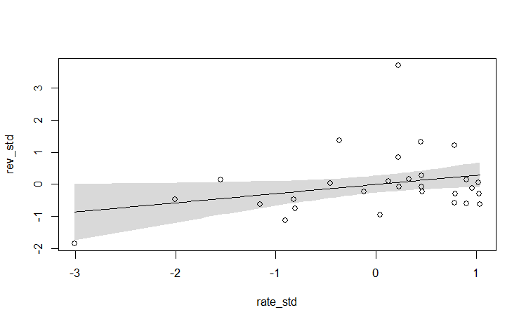

```r
shade( ci , rate_seq )
```

```r
m7h1.2 <- quap(
  alist(
    rev_std ~ dnorm(mu,exp(log.sigma)),
    mu <- a + b_rate[1] * rate_std + b_rate[2] * rate_std^2,
    a ~ dnorm(.5,2),
    b_rate ~ dnorm(0,10),
    log.sigma ~ dnorm(0,1)
  ), data = d, start = list(b_rate = rep(0,2))
)

post <- extract.samples(m7h1.2)
rate_seq <- seq( from=min(d$rate_std) , to=max(d$rate_std) , length.out=100 )
l <- link( m7h1.2 , data=list( rate_std=rate_seq ) )
mu <- apply( l , 2 , mean )
ci <- apply( l , 2 , PI )
plot( rev_std ~ rate_std , data=d )
lines( rate_seq , mu )
```

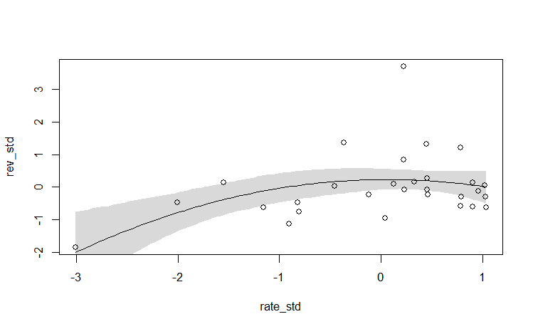

```r
shade( ci , rate_seq )
```

```r
m7h1.3 <- quap(
  alist(
    rev_std ~ dnorm(mu,exp(log.sigma)),
    mu <- a + b_rate[1] * rate_std + b_rate[2] * rate_std^2 + b_rate[3] * rate_std^3,
    a ~ dnorm(.5,2),
    b_rate ~ dnorm(0,10),
    log.sigma ~ dnorm(0,1)
  ), data = d, start = list(b_rate = rep(0,3))
)

post <- extract.samples(m7h1.3)
rate_seq <- seq( from=min(d$rate_std) , to=max(d$rate_std) , length.out=100 )
l <- link( m7h1.3 , data=list( rate_std=rate_seq ) )
mu <- apply( l , 2 , mean )
ci <- apply( l , 2 , PI )
plot( rev_std ~ rate_std , data=d )
lines( rate_seq , mu )
```

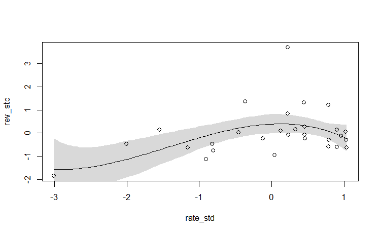

```r
shade( ci , rate_seq )
```

```r
m7h1.4 <- quap(
  alist(
    rev_std ~ dnorm(mu,exp(log.sigma)),
    mu <- a + b_rate[1] * rate_std + b_rate[2] * rate_std^2 + b_rate[3] * rate_std^3 + b_rate[4] * rate_std^4,
    a ~ dnorm(.5,2),
    b_rate ~ dnorm(0,10),
    log.sigma ~ dnorm(0,1)
  ), data = d, start = list(b_rate = rep(0,4))
)

post <- extract.samples(m7h1.4)
rate_seq <- seq( from=min(d$rate_std) , to=max(d$rate_std) , length.out=100 )
l <- link( m7h1.4 , data=list( rate_std=rate_seq ) )
mu <- apply( l , 2 , mean )
ci <- apply( l , 2 , PI )
plot( rev_std ~ rate_std , data=d )
lines( rate_seq , mu )
```

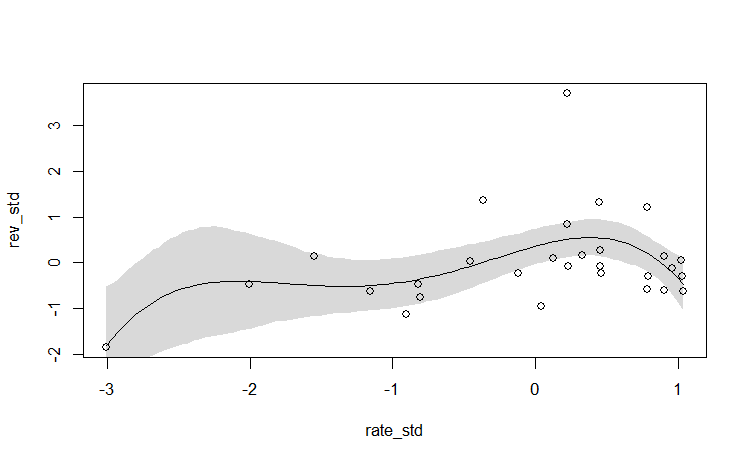

```r
shade( ci , rate_seq )
```

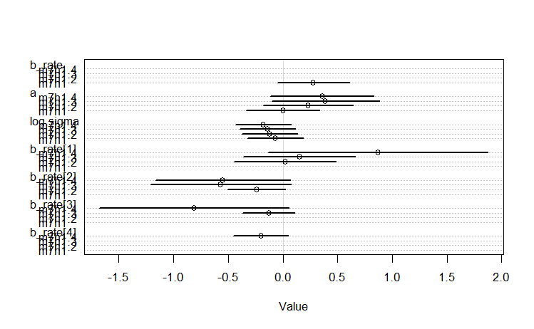

```r
plot(coeftab(m7h1, m7h1.2, m7h1.3, m7h1.4))
```

I don’t think that these models are really the right ones - I feel like it’s missing some kind of confound or something. Maybe there are governing characteristics of the countries that change the slope of the relationship? Anyways for most of the graph the relationship is positive. Where does the US fit into this picture?

## 7H2

```r
set.seed(24071847)
PSIS_m7h1 <- PSIS(m7h1,pointwise=TRUE) %>%
  add_column(d)# %>%
```

```
Some Pareto k values are very high (>1). Set pointwise=TRUE to inspect individual points.
```

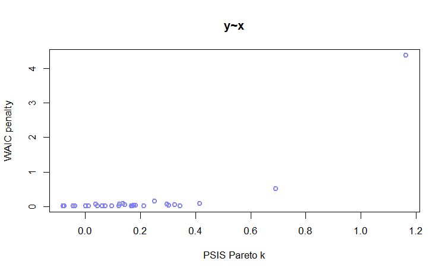

```r
  #pull(k) %>% hist()

set.seed(24071847)
WAIC_m7h1 <- WAIC(m7h1,pointwise=TRUE)
plot( PSIS_m7h1$k , WAIC_m7h1$penalty , xlab="PSIS Pareto k" ,
ylab="WAIC penalty" , col=rangi2 , lwd=2 , main = "y~x")
```

```r
set.seed(24071847)
PSIS_m7h1.2 <- PSIS(m7h1.2,pointwise=TRUE) %>%
  add_column(d)# %>%
```

```
Some Pareto k values are very high (>1). Set pointwise=TRUE to inspect individual points.
```

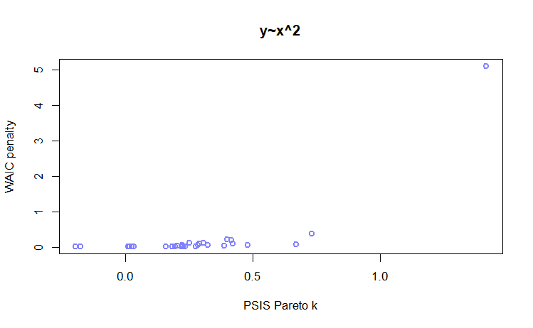

```r
  #pull(k) %>% hist()

set.seed(24071847)
WAIC_m7h1.2 <- WAIC(m7h1.2,pointwise=TRUE)
plot( PSIS_m7h1.2$k , WAIC_m7h1.2$penalty , xlab="PSIS Pareto k" ,
ylab="WAIC penalty" , col=rangi2 , lwd=2 , main = "y~x^2")
```

There are two outliers with a lot of influence for the first order model, and three in the second order model.

[figure not shown]

## 7H3

```r
d <- tibble(island = rep(c(1,2,3), each = 5),species = rep(c("A","B","C","D","E"), times = 3),
            prop = c(.2,.2,.2,.2,.2,.8,.1,.05,.025,.025,.05,.15,.7,.05,.05))


d |> split(d$island) |> map_dbl(\(x) -sum(x$prop*log(x$prop) ))
```

```
        1         2         3
1.6094379 0.7430039 0.9836003
```

Calculate KL divergences

```r
kld_islands <- map2(island_combos$q, island_combos$p)
```

[output not shown]

## 7H4

|  | WAIC | SE | dWAIC | dSE | pWAIC | weight |
| --- | --- | --- | --- | --- | --- | --- |
| m6.9 | 2714.0 | 37.54 | 0.0 | NA | 3.7 | 1 |
| m6.10 | 3101.9 | 27.74 | 387.9 | 35.4 | 2.3 | 0 |

WAIC comparison suggests that m6.9 will make better predictions about out of sample data than m6.10. However, WAIC is not intended to answer causal questions. Conditioning on a collider often reduces WAIC scores because more information is shared between the two predictor variables, but it can open a backdoor path and bias the estimate of the causal relationship between the exposure and the outcome.

## 7H5

```r
data(foxes)
d <- foxes %>%
  mutate(F = standardize(avgfood),
         G = standardize(groupsize),
         A = standardize(area),
         W = standardize(weight))

m7h5.1 <- quap(
  alist(
    weight ~ dnorm(mu, sigma),
    mu <- a + bA * A + bF * F + bG * G,
    a ~ dnorm(mean(d$weight),.5),
    bA ~ dnorm(0,.5),
    bF ~ dnorm(0,.5),
    bG ~ dnorm(0,.5),
    sigma ~ dexp(1)
  ),data = d
)

m7h5.2 <- quap(
  alist(
    weight ~ dnorm(mu, sigma),
    mu <- a + bF * F + bG * G,
    a ~ dnorm(mean(d$weight),.5),
    bF ~ dnorm(0,.5),
    bG ~ dnorm(0,.5),
    sigma ~ dexp(1)
  ),data = d
)

m7h5.3 <- quap(
  alist(
    weight ~ dnorm(mu, sigma),
    mu <- a + bA * A + bG * G,
    a ~ dnorm(mean(d$weight),.5),
    bA ~ dnorm(0,.5),
    bG ~ dnorm(0,.5),
    sigma ~ dexp(1)
  ),data = d
)

m7h5.4 <- quap(
  alist(
    weight ~ dnorm(mu, sigma),
    mu <- a + bF * F,
    a ~ dnorm(mean(d$weight),.5),
    bF ~ dnorm(0,.5),
    sigma ~ dexp(1)
  ),data = d
)

m7h5.5 <- quap(
  alist(
    weight ~ dnorm(mu, sigma),
    mu <- a + bA * A,
    a ~ dnorm(mean(d$weight),.5),
    bA ~ dnorm(0,.5),
    sigma ~ dexp(1)
  ),data = d
)

compare(m7h5.1,m7h5.2,m7h5.3,m7h5.4,m7h5.5)
```

|  | WAIC | SE | dWAIC | dSE | pWAIC | weight |
| --- | --- | --- | --- | --- | --- | --- |
| m7h5.1 | 363.0 | 16.31 | 0.0 | NA | 5.0 | 0.38 |
| m7h5.2 | 363.4 | 15.94 | 0.4 | 3.52 | 3.7 | 0.31 |
| m7h5.3 | 363.5 | 15.67 | 0.5 | 2.64 | 3.9 | 0.30 |
| m7h5.5 | 372.7 | 13.77 | 9.7 | 7.00 | 2.6 | 0.00 |
| m7h5.4 | 373.2 | 13.90 | 10.2 | 6.92 | 2.7 | 0.00 |

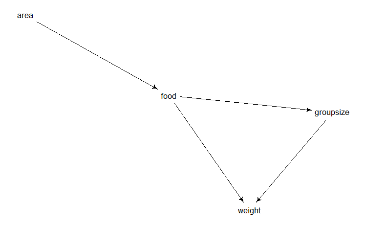

```r
sixm3 <- dagitty( "dag {
weight[outcome]
area -> food -> weight
area -> food -> groupsize -> weight
}")
drawdag( sixm3)
```

Model 1 has the lowest WAIC score, so it is expected to predict weight best out-of-sample. It looks like these models have WAIC scores that are different mainly because they have different numbers of parameters. The SE of the most complex model is the largest, which makes sense, because more parameters carry more uncertainty. Looks like the predictors aren’t that different in terms of predictive ability, which makes sense because the models exchanged area and food for each other, and removing one makes it more or less equivalent in causal terms to the other.